# 第8讲笔记

定量数据分析

# 引言

- 今天我们将继续探索线性模型的强大之处。
- 到目前为止，我们主要分析二元关系，即每次分析两个变量。
- 当我们同时纳入多个变量时，线性回归的优势才真正体现出来。

# 加入多个变量

- 在模型中加入更多变量很简单，只需使用加号+。
- 和以前一样，公式先写因变量，后面接波浪号~。
- 随后依次写入所需自变量，并以加号+分隔。

# 模型构建

- 模型构建与变量选择有多种方法。
- 两种常见方法是：
  1. 从具体到一般：从我们认为重要的变量出发，逐步加入其他变量。
  2. 从一般到具体：先纳入全部变量，再删除不显著的变量。
- 不同研究者和学科对哪种方法更好有不同看法。
- 不同方法适用于不同情境。

# 首先应该检查什么？

- 查看模型输出时，我通常会关注：
  1. 回归系数的正负号。
  2. 回归系数的统计显著性。
  3. 回归系数的大小。
  4. $R^2$的数值。
- 它们是否合理？
- 用我们的例子试试看。

# 如何处理不显著的变量？

- 模型建立完成时，我们会发现许多变量在统计上并不显著。
- 这意味着我们无法排除“该变量与因变量的真实关联为零”的可能性。
- 于是产生一个问题：应该将这些变量从模型中删除吗？

# 支持删除的观点

- 部分数据分析方法主张删除这些变量。
- 有多种自动化方法可以实现这一点。
- 如果无法排除不存在关联的可能，就无法据此作出确定的知识主张。
- 如果不能得出结论，就应该删除它。

# 反对删除的观点

- 作为社会科学研究者，我们通常采用演绎方法，而不是纯粹归纳方法。
- 我们根据理论和／或已有文献构建模型。
- 如果理论要求纳入某个变量，那么它就应该出现在模型中。
- 如果理论说明某个因素需要控制，那么保留它可能很有价值。
- 如果理论或文献预测某变量应显著，但结果却不显著，这可能提示我们需要检查研究过程（后面会进一步讨论）。

# 一些实用建议

- 有时我们会纳入一些事先无法确定是否显著的变量。
- 也许已有研究使用过这些变量，但结论不一致。
- 如果没有充分理由必须保留，而且它在统计上不显著，删除它可能是安全的。
- 如果变量的系数方向不符合预期且不显著，也可以考虑删除。
- 虽然存在自动变量选择方法，但在社会科学情境中，这通常不是好主意。

# 另一种测量指标

- 第一讲开始考虑模型时，我们提出了一些认为重要的概念。
- 我们假设教育与工资有关。
- 因此在模型中加入了教育指标。
- 不过，教育还可以通过其他指标来衡量。
- 如果结果不符合预期，可以考虑修改测量方式。
- 也可以尝试不同指标，检验分析方法的稳健性。

# 因子变量

- 回归中纳入了许多因子变量。
- 其中一些包含很多类别，可能太多了。
- 如果因子变量的许多类别均不显著，可以考虑合并类别、减少类别数量。
- 例如，原本把年龄分成20组，可以改为5组。
- 还可以改变参照类别；例如，用规模最小的行业作为参照组可能不合适。

# $R^2$值

- $R^2$反映自变量的变化可以解释因变量变异的多少。
- 许多人执着于将这个数值提高到尽可能大。
- 但好模型不一定有很高的\(R^2\)。
- 判断当前数值是否合理时，可以思考：
  - 是否有先前研究可供比较？
  - 你认为模型中包含的变量有多重要？

# $R^2$存在的问题

- 我们注意到，随着向模型增加变量，$R^2$总会上升。
- 即使新增变量不显著，\(R^2\)也不会下降。
- 为解决这一问题，有人提出了调整后的$R^2$。
- 它与普通\(R^2\)类似，但会对纳入无关变量进行惩罚。
- 方便的是，回归输出中通常会直接报告这一指标。

# 拟合优度

- $R^2$和调整后的$R^2$都是拟合优度指标。
- 这些指标试图说明模型对数据的拟合程度。
- 对于我们使用的回归模型，这两项是最常见的指标。
- 还有其他指标，适用于更广泛的回归模型。
- 赤池信息准则（AIC）
- 对数似然（Log-likelihood）
- 贝叶斯信息准则（BIC），也称施瓦茨信息准则或Schwarz–Bayes信息准则。

# 接下来呢？

- 我们已经讨论了一些可用于改进模型的原则。
- 可惜事情并没有那么简单。
- 只有满足某些假设，我们对模型结果的解释才是正确的。
- 偏离模型假设越多，研究结果的稳健性就越弱。
- 首先讨论可能出现哪些错误。
- 这里先假定数据能够代表我们关注的总体。

# 偏差

- “偏差”这个词会让建模者感到紧张。
- 如果模型中某个系数估计值的期望不等于总体中的真实参数值，该估计量就是有偏的。
- 形式上，无偏估计必须满足：$E[\hat{\beta}] = \beta$。
- 如果估计量平均而言无法得到总体参数，那就存在问题。
- 我们（可能）无法相信效应的方向和大小。
- 也（可能）无法对统计显著性作出有意义的判断。

# 一致性

- 估计量可以是有偏的，也可以是无偏的。
- 它还可以是一致的或不一致的。
- 如果估计量具有一致性，那么即使有偏，也可能有所弥补。
- 当样本量足够大时，一致估计量会收敛到总体参数。
- 形式上，一致性要求：$\textrm{plim}_{n\to \infty} \hat{\beta} = \beta$。
- 如果估计量一致，那么足够大的数据量可能减轻偏差问题。
- 如果既有偏又不一致，就有麻烦了。

# 有效性

- 虽然不是最关键的，但我们通常希望估计量尽可能有效率。
- 估计量效率越高，估计结果越精确，也就是标准误越小。
- 如果估计量效率低，我们可能犯第二类错误。
- 这不是最严重的问题，但仍值得留意。

# 最佳线性无偏估计量（BLUE）

- 在特定的一组假设下，普通最小二乘回归（OLS）是最佳线性无偏估计量。
- 它是无偏的，即$E[\hat{\beta}]=\beta$。
- 在线性估计量中，它具有最小方差，即具有效率优势。
- 使用这个模型时，必须了解背后的假设。

# 引言摘录

> 作出假设是一件危险的事。

阿加莎·克里斯蒂（Agatha Christie）

> 作出假设是一件危险的事；就像制作其他危险的东西——例如炸弹或草莓酥饼——哪怕只犯一点点错误，也可能使自己陷入大麻烦。

雷蒙尼·斯尼科特，《严酷的学校》（Lemony Snicket, The Austere Academy）

> 欧几里得教会我：没有假设，就没有证明。因此，在任何论证中，都应审视其假设。

E. T. 贝尔（E. T. Bell）

# 模型假设

我们将讨论以下假设（引自Peter Kennedy的《计量经济学指南》）：

1. 模型设定正确。
2. 残差方差相同，且残差彼此独立。
3. 自变量之间不存在完全线性关系。
4. 自变量是固定的，且测量不存在误差。
5. 残差的期望值为零。

# 假设1

- 如果违反这一假设，其余分析可能全部失去意义。
- 这个假设包含许多方面。
- 既然刚谈过变量选择，就从这里开始。

# 遗漏变量偏差

- 在本例中，我们关心男性与女性之间是否存在小时工资差异。
- 我们想关注歧视问题：假设两个人除了性别以外各方面都相同，他们的工资会不同吗？
- 因此，我们必须控制同时符合以下条件的所有因素：
  1. 会影响工资。
  2. 在不同性别之间存在差异。
- 如果不纳入这些因素，就会产生遗漏变量偏差。

# 遗漏变量偏差

- 这是严重的偏差形式，会影响我们对模型的解释。
- 如果遗漏这些变量，性别系数就会在与它们相关的程度上吸收遗漏变量的效应。
- 我们应当在回归中纳入所有此类变量。
- 对于无法控制的因素，也应加以说明，并相应调整结果解释。
- 可以将它们列为研究局限性。

# 纳入无关变量

- 理想情况下，我们不希望在模型中加入无关变量。
- 加入无关变量会降低估计效率。
- 还会使模型更难向读者呈现。
- 偏差比效率损失更严重，因此拿不准时可以先将变量保留在模型中。

# 如何决定纳入哪些变量？

- 不要忘记，选择过程应由理论和已有研究指导。
- 社会科学家通常不会机械地决定纳入哪些变量。
- 要花时间反思自己所做的分析是否合理。
- 随时可以回到文献中，看看前人如何处理。

# 关于纳入哪些观测值

- 刚才我一直讨论模型中该纳入哪些变量。
- 更早之前，我们讨论过哪些人应当包含在总体和样本中。
- 但离群值怎么办？也就是明显远离其他数据点的观测。
- 不同学科和作者对此有不同看法。
- 考虑一个虚构例子，它并不是劳动力调查数据。

# 制作一组模拟数据

```r
fake_data <- data.frame(age= c(20, 23, 25, 26, 28, 30, 32, 33, 65 ),
                   wage = c(10, 11, 15, 9, 8, 20, 22, 25, 200))
```

# 工资与年龄

```
##
## Call:
## lm(formula = wage ~ age, data = .)
##
## Residuals:
##     Min      1Q  Median      3Q     Max
## -18.075 -12.517  -2.494  12.556  25.575
##
## Coefficients:
##              Estimate Std. Error t value Pr(>|t|)
## (Intercept) -105.8059    14.7808  -7.158 0.000184 ***
## age            4.5115     0.4379  10.302 1.76e-05 ***
## ---
## Signif. codes:  0 '***' 0.001 '**' 0.01 '*' 0.05 '.' 0.1 ' ' 1
##
## Residual standard error: 16.48 on 7 degrees of freedom
## Multiple R-squared:  0.9381, Adjusted R-squared:  0.9293
## F-statistic: 106.1 on 1 and 7 DF,  p-value: 1.758e-05
```

# 工资与年龄

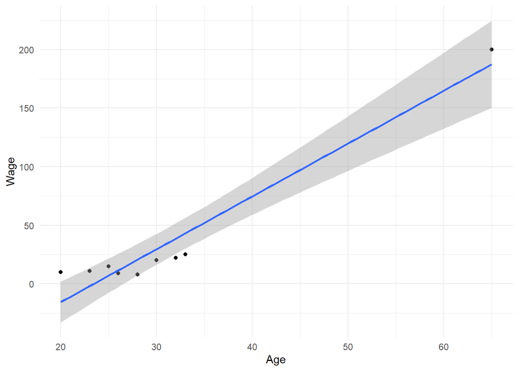

# 排除离群值后的工资与年龄

```
##
## Call:
## lm(formula = wage ~ age, data = .)
##
## Residuals:
##     Min      1Q  Median      3Q     Max
## -7.9938 -0.6668  1.5989  2.5832  3.3274
##
## Coefficients:
##             Estimate Std. Error t value Pr(>|t|)
## (Intercept) -15.8075    10.2675  -1.540   0.1746
## age           1.1358     0.3741   3.036   0.0229 *
## ---
## Signif. codes:  0 '***' 0.001 '**' 0.01 '*' 0.05 '.' 0.1 ' ' 1
##
## Residual standard error: 4.44 on 6 degrees of freedom
## Multiple R-squared:  0.6057, Adjusted R-squared:   0.54
## F-statistic: 9.218 on 1 and 6 DF,  p-value: 0.02292
```

# 工资与年龄

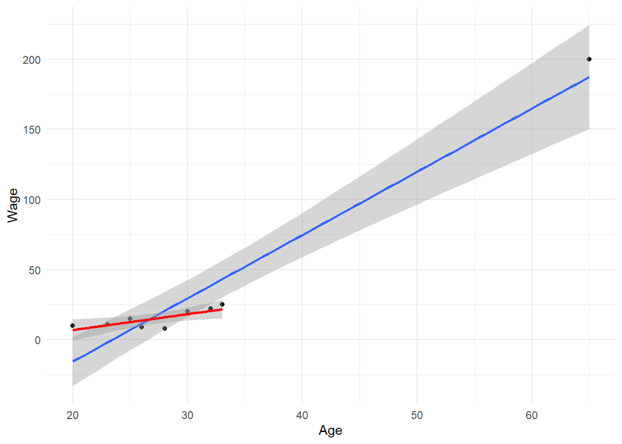

# 识别离群值

- 描述数据时，就可以开始识别离群值。
- 是否存在看起来与其他点明显不同的数据点？
- 首先要判断该数值是否可能真实存在。
- 例如，−10岁或634岁都是不合理的年龄值。
- 这些记录应被剔除。

# 如果数值确实有效呢？

- 有些学科建议剔除离群值。
- 要避免仅仅因为某个观测不符合模型预期，就把它删除。
- 在纠结之前，先检查它是否真的改变分析结果。
- 在虚构例子中，它显然产生了影响。
- 可以查看“残差与杠杆值图”，帮助判断某个点的影响力。

# 残差与杠杆值

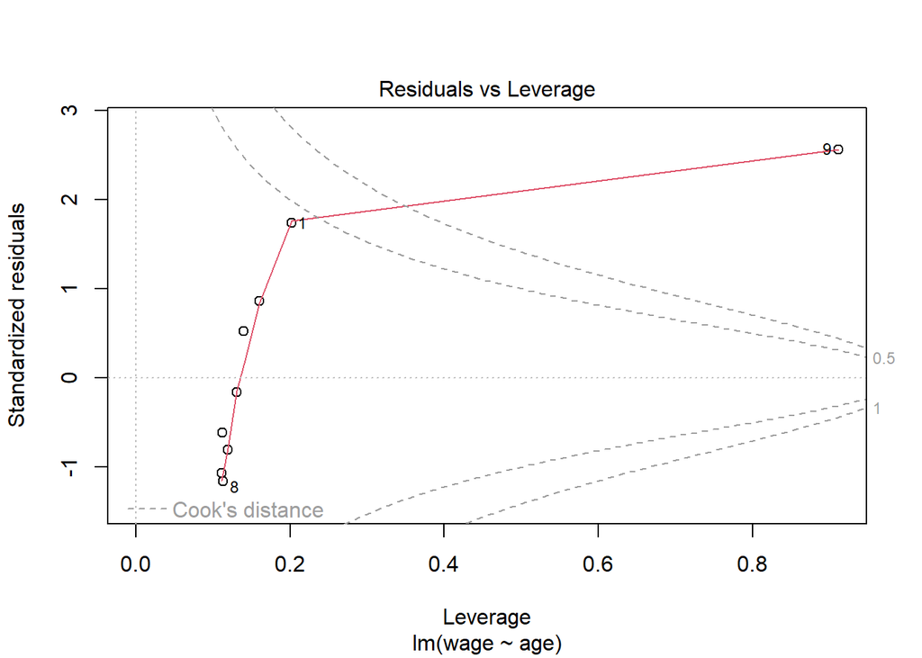

```r
fake_data %>% lm(wage ~ age, data=.) %>% plot(which=5)
```

# 残差与杠杆值

- 图中表明第9个观测具有很大的影响力。
- 排除它后，结果发生了明显变化。
- 因此必须认真考虑是否保留它。
- 我们可能怀疑这条记录是否被准确录入。
- 在这个例子中，它的因变量和自变量取值都非常极端。
- 我可能建议限制样本范围，并说明研究结论未必适用于年龄较大的人。

# 排除极端值后的残差与杠杆值图

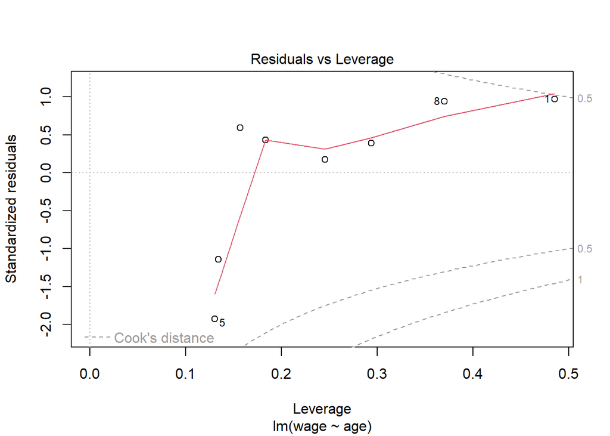

```r
fake_data %>%  filter(age<40) %>% lm(wage ~ age, data=.) %>% plot(which=5)
```

# 一些思考

- 人们经常为离群值苦恼，其实它们通常对结果没有什么影响。
- 当样本量很大时，离群值往往影响很小。
- 有些学科建议机械地对离群值应用严格规则。
- 甚至还有自动化处理离群值的方法。
- 我认为这些方法非常糟糕。
- 始终要独立思考，理解自己所做分析的实际意义。

# 我们回归模型的残差与杠杆值图

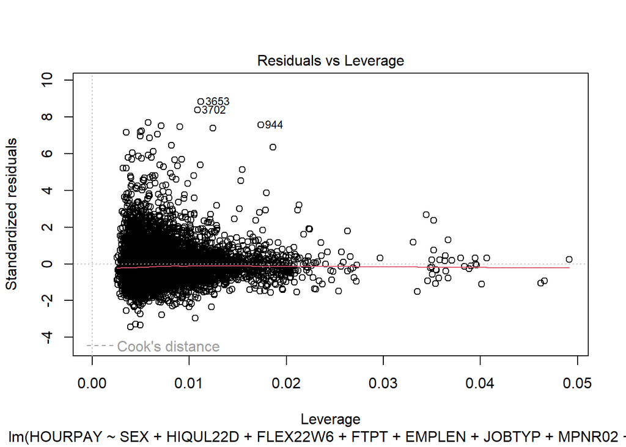

```r
lm(HOURPAY ~ SEX + HIQUL22D + FLEX22W6 + FTPT + EMPLEN + JOBTYP + MPNR02 + MARSTA + INDE07M + NSECMJ20 + AGE + GOR9D, data=lfs) %>% plot(which=5)
```

# 结果解释

- 数据中确实存在一些离群值，但它们对回归线的影响很小。
- 因此不必太过担心。

# 总结

- 我们在线性回归的理解上前进了不少。
- 从二元模型转向了多元模型。
- 也开始讨论模型假设。
- 还有许多其他假设需要介绍。
- 接下来我们将继续讨论这些假设，并学习如何改进模型。